# MA22019 - Overview

5 February 2025

## Plan for Today

- Overview of the course
- Data cleaning (Section 1.1)
- Working with a single data frame (Section 1.2)

## Welcome to the World of Data Science!

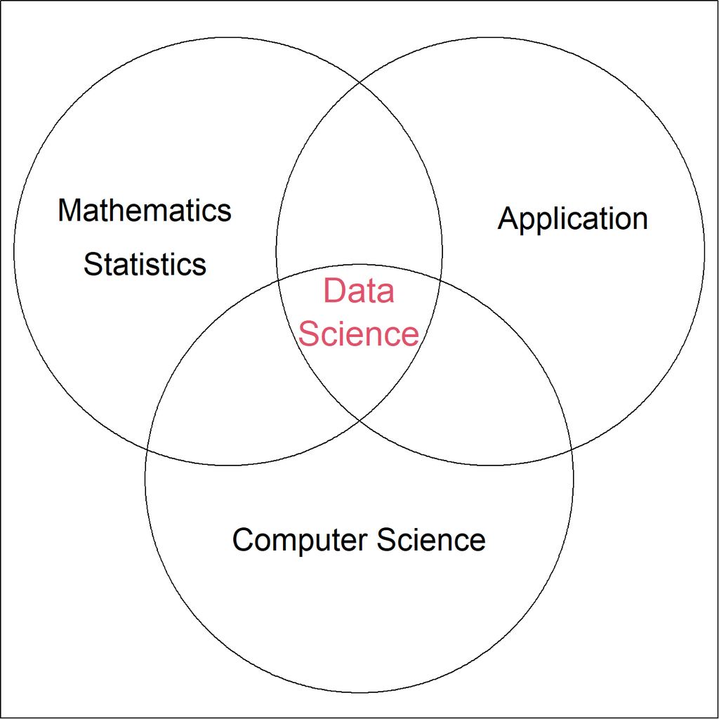

## Content and Schedule

| Week | Topic |
| --- | --- |
| 1 - 2 | Data Wrangling |
| 2 - 3 | Data Visualization |
| 4 | Coursework 1 |
| 5 - 6 | Text Data Analysis |
| 7 - 9 | Spatial Data Analysis |
| 10 - 11 | Coursework 2 |

## Outlook

At the end of the course, you will be able to produce and interpret graphics such as

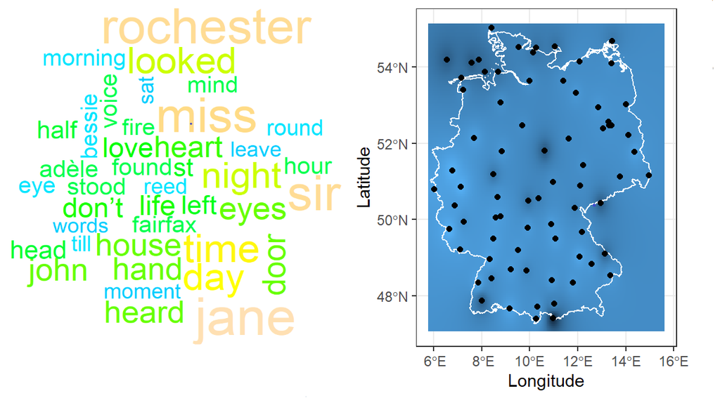

## R and RStudio

We will use R throughout this course.

I recommend that you install R and RStudio on your own computer / laptop.

You should run the commands in “InstallPackages.R” to ensure you have all the relevant R packages.

Except for patchwork, the packages we use for Weeks 1-4 are already installed on the campus computers.

## Timetable

The number of hours varies a bit across weeks

- In-person lecture on Wednesday 10:15-12:05 (W 1-3, 5-9) / 10:15-11:05 (W 4,10,11)
- Online problem class (on Zoom) on Friday 14:15-15:05 (W 1-3)

**Tutorial:** Take place on Tuesday. Please check your timetable for time and location. No tutorial in Week 5!

**Getting Help:**

- Use the Padlet board or send me an email
- **Office Hour:** Monday 9:00-11:00 (in-person)

## What can you find on Moodle?

- Lecture notes in HTML and PDF format
- Data sets and R files to reproduce the results in the lecture notes
- Material for the problem class
- Problem sheets and solutions
- Slides from the lecture
- Cheat sheets for some of the R packages we will be using
- Coursework

## Problem Sheets and Coursework

Problem sheets provide

- Exercises for revision. Check answers on Moodle.
- Tutorial questions: More advanced than exercises.
- Homework question: Similar to coursework questions.

Your mark will be determined by two pieces of coursework:

- CW1 (40%): Set 15:00 on 21 Feb, due 17:00 on 28 Feb.
- CW2 (60%): Set at the start of Week 10, due in Week 11.

**You will receive individual feedback and provisional marks for CW1 before the release of CW2.**

## Changes made based on OUE feedback

1. Additional problem classes in Weeks 1-3
2. More guidance on how coursework will be marked.

Each coursework question will be assessed as a whole based on:

- Correctness
- Quality
- Presentation and conciseness

To reflect this, your answer to the homework question will be marked as (i) <50%, (ii) 50-69% or (iii) >=70%.

## Example

Suppose we had ambulance response data which includes:

- Waiting time of the patient
- Ambulance response category (1=‘life-threatening’, 4=‘non-urgent’)
- Time patient spent in hospital

You are asked to consider the question:

*“Does the data suggest that the length of stay in hospital increases with the time until the ambulance arrives?”*

I will present three answers, and you have to decide a mark.

## Any questions?

**Let’s have a 5-minute break.**